# Old cars

Yunfan Li 李云帆

2019/3/6

### stuID：“16302010002”

```r
setwd("E:\\BaiduNetdiskDownload/")
dat0 <- read.csv("cars.csv", header=1, stringsAsFactors=FALSE, fileEncoding="GB2312")
```

```r
d1 <- subset(dat0,pailiang != -1|paifang != -1)
```

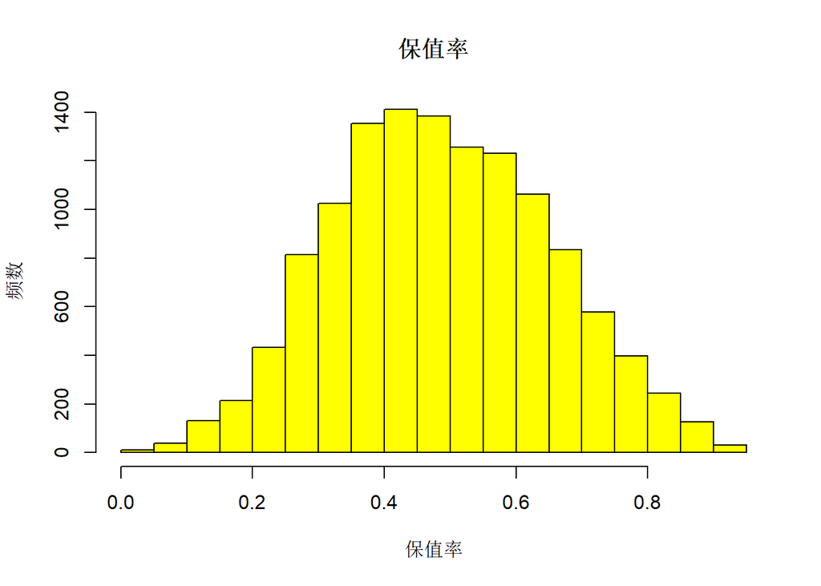

```r
baozhilv <- d1$baojia/d1$yuanjia
hist(baozhilv,col="yellow",xlab="保值率",ylab="频数", main="保值率")
```

#### 由柱状图可以看出保值率和频数之间的关系基本满足一个左右对称的分布，其中保值率集中在0.5附近

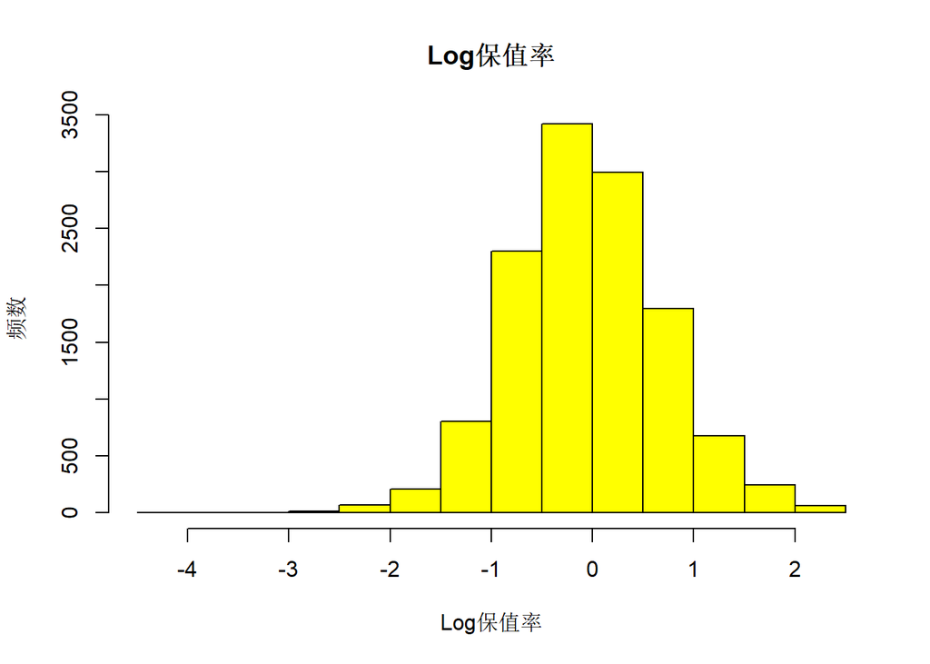

```r
logbaozhilv <- log(d1$baojia/(d1$yuanjia-d1$baojia))
hist(logbaozhilv,col="yellow",xlab="Log保值率",ylab="频数", main="Log保值率")
```

#### 从柱状图可以看出对数保值率和频数之间的关系勉强满足一个钟形曲线的对称分布，其中对数保值率集中在0附近

```r
vecBZL <- as.data.frame(baozhilv)
#vecBZL<-rowSums(vecBZL*is.finite(vecBZL),na.rm=TRUE)
vecBZL[sapply(vecBZL, is.infinite)] <- NA
vecBZL<-na.omit(vecBZL)
vecBZL<-as.numeric(unlist(vecBZL))
```

[output not shown]

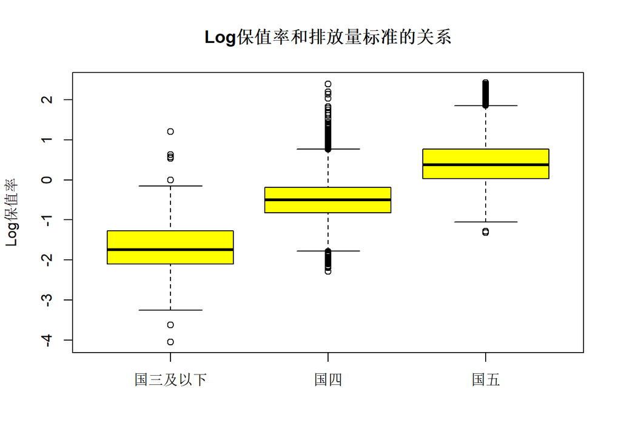

```r
paifang<-as.array(d1$paifang)
for(i in c(1:nrow(paifang))){
  if(paifang[i]=="国一"|paifang[i]=="国二"|paifang[i]=="国三") paifang[i]="国三及以下"
}
dataset1 <- data.frame(value = logbaozhilv, group = factor(paifang))
boxplot(value ~ group,main="Log保值率和排放量标准的关系",col="yellow",ylab="Log保值率",dataset1)
```

#### 由箱线图可以看出，log保值率和排放标准的关系基本可以描述为：国三及以下，国四，国五排标的各自的对数保值率呈阶梯型上升趋势，方差信息不能从图中明确感知（我认为方差相似）

```r
  pailiangfct<-as.data.frame(d1$pailiang)
pailiangfactor<-function(pailiangfct){
  for(i in c(1:nrow(pailiangfct))){
    if(pailiangfct$pl[1,i]<1) pailiangfct$jc[i]="微型轿车"
    else if (pailiangfct$pl[1,i]<1.6) pailiangfct$jc[i]="普通级轿车"
    else if (pailiangfct$pl[1,i]<2.5) pailiangfct$jc[i]="中级轿车"
    else if (pailiangfct$pl[1,i]<4.0) pailiangfct$jc[i]="中高级轿车"
    else if (pailiangfct$pl[1,i]>=4.0) pailiangfct$jc[i]="高级轿车"
  }
  pailiangfct
}
```

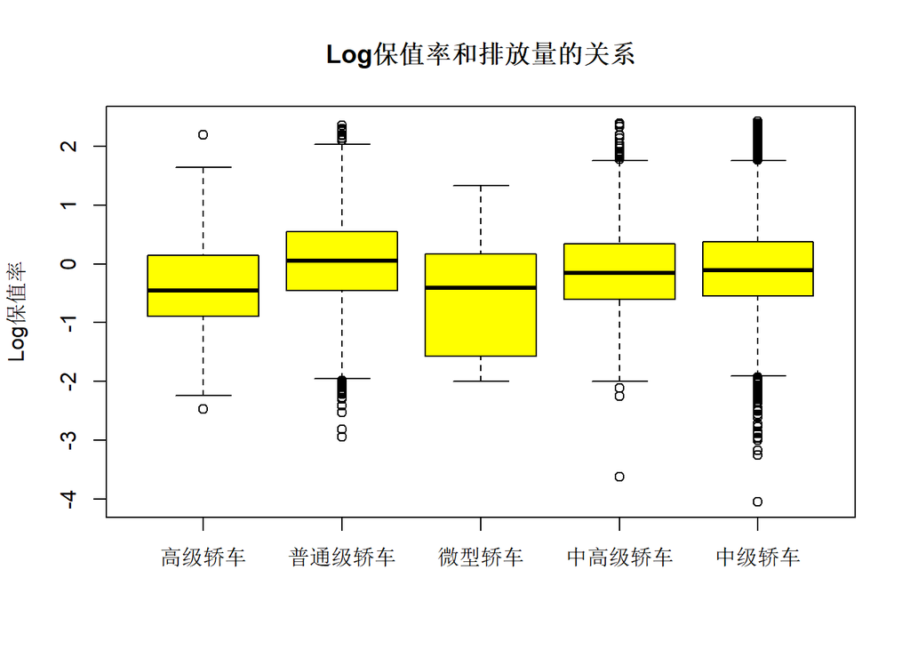

```r
for(i in c(1:nrow(pailiangfct))){
  if(pailiangfct$`d1$pailiang`[i]<1) pailiangfct$jc[i]="微型轿车"
  else if (pailiangfct$`d1$pailiang`[i]<1.6) pailiangfct$jc[i]="普通级轿车"
  else if (pailiangfct$`d1$pailiang`[i]<2.5) pailiangfct$jc[i]="中级轿车"
  else if (pailiangfct$`d1$pailiang`[i]<4.0) pailiangfct$jc[i]="中高级轿车"
  else if (pailiangfct$`d1$pailiang`[i]>=4.0) pailiangfct$jc[i]="高级轿车"
}
dataset2 <- data.frame(value = logbaozhilv, group = factor(pailiangfct$jc))
boxplot(value ~ group,main="Log保值率和排放量的关系",col="yellow",ylab="Log保值率",dataset2)
```

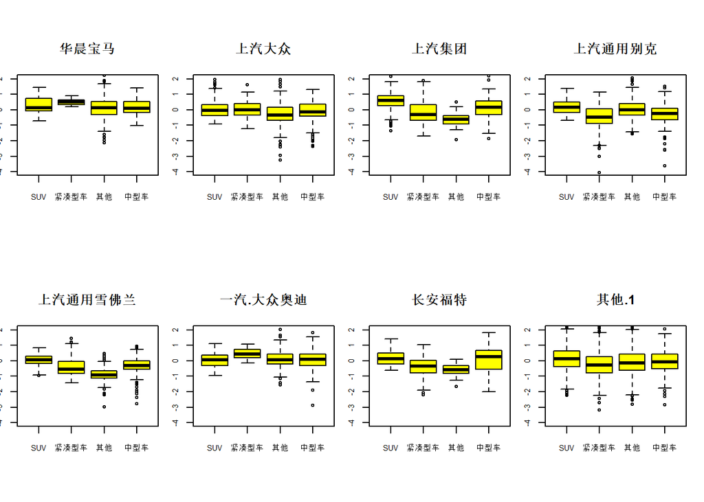

```r
d1 <- read.csv("cars-final.csv", header=1, stringsAsFactors=FALSE, fileEncoding="GB2312")
func<-function(a,cxname){
  myvars <- c("其他","SUV","中型车","紧凑型车")
  chexing<-a[myvars]
  logbaozhilv <- as.data.frame(log(a$baojia/(a$yuanjia-a$baojia)))

  #chexing<-merge(chexing, rep("",time=nrow(chexing)))
  chexing$logbaozhilv<-logbaozhilv
  #nrow(chexing)
  #cx<-list(rep("",time=nrow(chexing)))
  cx <- rep("",time=nrow(chexing))
  #dim(cx) <- c(nrow(chexing),1)
  chexing$cx<-cx
  for(i in c(1:nrow(chexing))){
    if(chexing[i,"SUV"]==1)
      chexing[i,ncol(chexing)]="SUV"
    else if(chexing[i,"紧凑型车"]==1)
      chexing[i,ncol(chexing)]="紧凑型车"
    else if(chexing[i,"中型车"]==1)
      chexing[i,ncol(chexing)]="中型车"
    else
      chexing[i,ncol(chexing)]="其他"
  }
  names<-c("cx","logbaozhilv")
  chexing<-chexing[names]
  logbaozhilv<-as.numeric(unlist(chexing$logbaozhilv))
  dataset1 <- data.frame(value = logbaozhilv, group = factor(chexing$cx))
  dataset1
  plotname<-paste(cxname)
  graph<-boxplot(value ~ group,main=plotname,col="yellow",ylab="Log保值率",dataset1,ylim=c(-4,2))
  #axis(2,at=seq(-4,2,1))
  graph
}
```

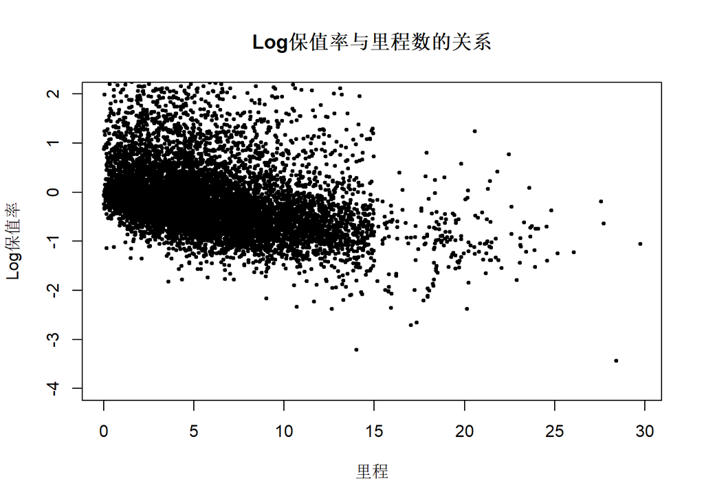

```r
licheng<-as.data.frame(d1$licheng)
logbaozhilv<-as.data.frame(log(d1$baojia/(d1$yuanjia-a$baojia)))
plot(x=as.numeric(unlist(licheng)), y=as.numeric(unlist(logbaozhilv)), main="Log保值率与里程数的关系", xlab="里程", ylab="Log保值率",ylim=c(-4,2),pch=19,col="black",bg="black",cex=0.5)
```

#### 散点图中可以明显得出对数保值率和里程之间呈负相关。实际中如果关注二手车买卖，里程决定了车的折旧程度，我们有理由相信车开过的里程越多，其各个部件的损耗也会相应增大，因而其成色也会降低，自然卖价也会打折扣。